# first_touch_eda

```python
import os
import pandas as pd
import numpy as np
import matplotlib
import matplotlib.pyplot as plt
import seaborn as sns
import plotly
from statsmodels.tsa.seasonal import seasonal_decompose

plt.style.use('fivethirtyeight')
%matplotlib inline
```

```python
data_path = "../data/raw/"
```

```python
os.listdir(data_path)
```

```
['olist_orders_dataset.csv',
 'olist_order_items_dataset.csv',
 'olist_order_reviews_dataset.csv',
 'olist_products_dataset.csv']
```

```python
orders = pd.read_csv(data_path + 'olist_orders_dataset.csv')
order_items = pd.read_csv(data_path + 'olist_order_items_dataset.csv')
order_reviews = pd.read_csv(data_path + 'olist_order_reviews_dataset.csv')
products = pd.read_csv(data_path + 'olist_products_dataset.csv')
```

# Conhecendo individualmente cada DataFrame

# Orders DataFrame

```python
print("Shape =", orders.shape)
display(orders.sample(3))
```

```
Shape = (99441, 8)
```

|  | order_id | customer_id | order_status | order_purchase_timestamp | order_approved_at | order_delivered_carrier_date | order_delivered_customer_date | order_estimated_delivery_date |
| --- | --- | --- | --- | --- | --- | --- | --- | --- |
| 17331 | 7f8627b25121727150b46207617a168a | a47974ac6596398820508728a779e2df | delivered | 2017-05-18 22:42:50 | 2017-05-18 22:55:18 | 2017-05-22 13:09:26 | 2017-06-02 13:51:29 | 2017-06-09 00:00:00 |
| 94955 | e0e95960e8abbd803bbd543d2225c328 | da2115c0723c07a68e9062f4d5aad9f3 | delivered | 2018-04-25 07:48:30 | 2018-04-26 04:10:45 | 2018-04-26 13:48:00 | 2018-05-08 14:56:51 | 2018-05-18 00:00:00 |
| 60489 | bd69cd564f711eddada0e30038e89558 | d9f898812ce971d417c2ecd100b60c32 | delivered | 2017-06-24 20:03:04 | 2017-06-24 20:10:29 | 2017-06-26 18:43:29 | 2017-07-06 14:52:57 | 2017-07-26 00:00:00 |

### Distribuição dos diferentes status possíveis

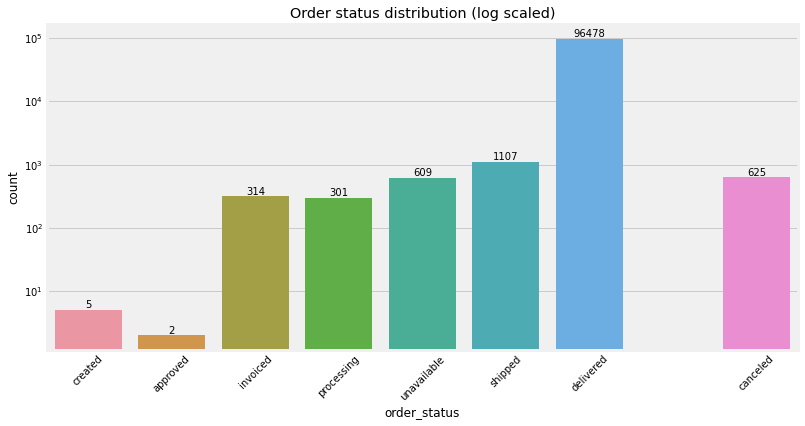

```python
plt.figure(figsize=(12,6))

ax = sns.countplot(data=orders, x='order_status', order=['created','approved','invoiced','processing','unavailable','shipped','delivered','','canceled'])

ax.set_yscale("log")
rects = ax.patches

for rect in rects:
    height = rect.get_height()
    if pd.isna(height):
        continue
    ax.text(rect.get_x() + rect.get_width() / 2, height, int(height), ha='center', va='bottom')

plt.xticks(rotation=45)
plt.title("Order status distribution (log scaled)")
plt.show()
```

```python
# transforming text datetime columns to datetime dtype
orders_cols = orders.columns
for col in orders_cols[3:]:
    orders[col] = pd.to_datetime(orders[col])
```

```python
orders.describe(datetime_is_numeric=True, include='all')
```

|  | order_id | customer_id | order_status | order_purchase_timestamp | order_approved_at | order_delivered_carrier_date | order_delivered_customer_date | order_estimated_delivery_date |
| --- | --- | --- | --- | --- | --- | --- | --- | --- |
| count | 99441 | 99441 | 99441 | 99441 | 99281 | 97658 | 96476 | 99441 |
| unique | 99441 | 99441 | 8 | NaN | NaN | NaN | NaN | NaN |
| top | 812855c58b365035c104626bd744eddc | 79fb5aa7830e13fdf7101a22967c0721 | delivered | NaN | NaN | NaN | NaN | NaN |
| freq | 1 | 1 | 96478 | NaN | NaN | NaN | NaN | NaN |
| mean | NaN | NaN | NaN | 2017-12-31 08:43:12.776581120 | 2017-12-31 18:35:24.098800128 | 2018-01-04 21:49:48.138278656 | 2018-01-14 12:09:19.035542272 | 2018-01-24 03:08:37.730111232 |
| min | NaN | NaN | NaN | 2016-09-04 21:15:19 | 2016-09-15 12:16:38 | 2016-10-08 10:34:01 | 2016-10-11 13:46:32 | 2016-09-30 00:00:00 |
| 25% | NaN | NaN | NaN | 2017-09-12 14:46:19 | 2017-09-12 23:24:16 | 2017-09-15 22:28:50.249999872 | 2017-09-25 22:07:22.249999872 | 2017-10-03 00:00:00 |
| 50% | NaN | NaN | NaN | 2018-01-18 23:04:36 | 2018-01-19 11:36:13 | 2018-01-24 16:10:58 | 2018-02-02 19:28:10.500000 | 2018-02-15 00:00:00 |
| 75% | NaN | NaN | NaN | 2018-05-04 15:42:16 | 2018-05-04 20:35:10 | 2018-05-08 13:37:45 | 2018-05-15 22:48:52.249999872 | 2018-05-25 00:00:00 |
| max | NaN | NaN | NaN | 2018-10-17 17:30:18 | 2018-09-03 17:40:06 | 2018-09-11 19:48:28 | 2018-10-17 13:22:46 | 2018-11-12 00:00:00 |

*- Estamos olhando para um range de aproximadamente dois anos de vendas.*  
*- Os IDs dos clientes não se repetem, portanto não temos mais de uma ordem feita pelo mesmo cliente.*

```python
orders.isna().sum()
```

```
order_id                            0
customer_id                         0
order_status                        0
order_purchase_timestamp            0
order_approved_at                 160
order_delivered_carrier_date     1783
order_delivered_customer_date    2965
order_estimated_delivery_date       0
dtype: int64
```

*- A data estimada de entrega nunca esta vazia, deve significar que algum sistema inputa isto automaticamente no momento da criação do pedido.*

Pode ser que haja sentido em possuir pedidos com valores vazios nestas três colunas ('order_approved_at','order_delivered_carrier_date' e 'order_delivered_customer_date').  
Investigar isto pode nos ajudar a entender melhor a forma de coleta destes dados, trazendo confiança para os próximos passos e levantando dúvidas para a origem do Dataset.

### Pedidos sem data de aprovação

```python
orders[orders['order_approved_at'].isna() == True].sample(3)
```

|  | order_id | customer_id | order_status | order_purchase_timestamp | order_approved_at | order_delivered_carrier_date | order_delivered_customer_date | order_estimated_delivery_date |
| --- | --- | --- | --- | --- | --- | --- | --- | --- |
| 60706 | 9bd5312d12f48b04a460f702baff3d8c | 4d145fd1d3245cbb3697dd41b4bcf19b | canceled | 2016-10-06 20:43:30 | NaT | NaT | NaT | 2016-11-16 |
| 56589 | dd38e535112fb5094b53b1997c4eda52 | 806f601fd9936f4d97179a15b3b4c3ad | canceled | 2018-08-13 13:01:54 | NaT | NaT | NaT | 2018-08-21 |
| 48401 | 7002a78c79c519ac54022d4f8a65e6e8 | d5de688c321096d15508faae67a27051 | delivered | 2017-01-19 22:26:59 | NaT | 2017-01-27 11:08:05 | 2017-02-06 14:22:19 | 2017-03-16 |

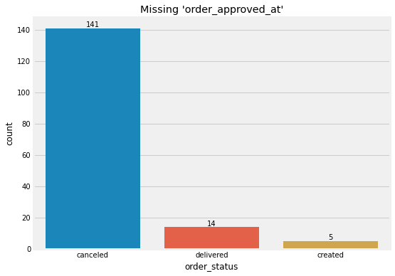

```python
plt.figure(figsize=(8,6))

ax = sns.countplot(data=orders[orders['order_approved_at'].isna()], x='order_status')
rects = ax.patches

for rect in rects:
    height = rect.get_height()
    if pd.isna(height):
        continue
    ax.text(rect.get_x() + rect.get_width() / 2, height, int(height), ha='center', va='bottom')

plt.title("Missing 'order_approved_at'")
plt.show()
```

*- Faz sentido que ordens canceladas ou apenas criadas(aguardando aprovação) não tenham sido aprovadas em nenhum momento. Para isto, decidiram manter o campo vazio na coleta.*  
**Vamos investigar melhor as ordens com status "delivered" que não possuem data de aprovação.**

```python
orders[orders['order_approved_at'].isna()].isna().sum()
```

```
order_id                           0
customer_id                        0
order_status                       0
order_purchase_timestamp           0
order_approved_at                160
order_delivered_carrier_date     146
order_delivered_customer_date    146
order_estimated_delivery_date      0
dtype: int64
```

```python
nan_approval_delivered = orders[(orders['order_approved_at'].isna()) & (orders['order_delivered_customer_date'].notna())]
print(f"Número de ordens entregues com data de aprovação vazia: {nan_approval_delivered.shape[0]}.")
nan_approval_delivered
```

```
Número de ordens entregues com data de aprovação vazia: 14.
```

|  | order_id | customer_id | order_status | order_purchase_timestamp | order_approved_at | order_delivered_carrier_date | order_delivered_customer_date | order_estimated_delivery_date |
| --- | --- | --- | --- | --- | --- | --- | --- | --- |
| 5323 | e04abd8149ef81b95221e88f6ed9ab6a | 2127dc6603ac33544953ef05ec155771 | delivered | 2017-02-18 14:40:00 | NaT | 2017-02-23 12:04:47 | 2017-03-01 13:25:33 | 2017-03-17 |
| 16567 | 8a9adc69528e1001fc68dd0aaebbb54a | 4c1ccc74e00993733742a3c786dc3c1f | delivered | 2017-02-18 12:45:31 | NaT | 2017-02-23 09:01:52 | 2017-03-02 10:05:06 | 2017-03-21 |
| 19031 | 7013bcfc1c97fe719a7b5e05e61c12db | 2941af76d38100e0f8740a374f1a5dc3 | delivered | 2017-02-18 13:29:47 | NaT | 2017-02-22 16:25:25 | 2017-03-01 08:07:38 | 2017-03-17 |
| 22663 | 5cf925b116421afa85ee25e99b4c34fb | 29c35fc91fc13fb5073c8f30505d860d | delivered | 2017-02-18 16:48:35 | NaT | 2017-02-22 11:23:10 | 2017-03-09 07:28:47 | 2017-03-31 |
| 23156 | 12a95a3c06dbaec84bcfb0e2da5d228a | 1e101e0daffaddce8159d25a8e53f2b2 | delivered | 2017-02-17 13:05:55 | NaT | 2017-02-22 11:23:11 | 2017-03-02 11:09:19 | 2017-03-20 |
| 26800 | c1d4211b3dae76144deccd6c74144a88 | 684cb238dc5b5d6366244e0e0776b450 | delivered | 2017-01-19 12:48:08 | NaT | 2017-01-25 14:56:50 | 2017-01-30 18:16:01 | 2017-03-01 |
| 38290 | d69e5d356402adc8cf17e08b5033acfb | 68d081753ad4fe22fc4d410a9eb1ca01 | delivered | 2017-02-19 01:28:47 | NaT | 2017-02-23 03:11:48 | 2017-03-02 03:41:58 | 2017-03-27 |
| 39334 | d77031d6a3c8a52f019764e68f211c69 | 0bf35cac6cc7327065da879e2d90fae8 | delivered | 2017-02-18 11:04:19 | NaT | 2017-02-23 07:23:36 | 2017-03-02 16:15:23 | 2017-03-22 |
| 48401 | 7002a78c79c519ac54022d4f8a65e6e8 | d5de688c321096d15508faae67a27051 | delivered | 2017-01-19 22:26:59 | NaT | 2017-01-27 11:08:05 | 2017-02-06 14:22:19 | 2017-03-16 |
| 61743 | 2eecb0d85f281280f79fa00f9cec1a95 | a3d3c38e58b9d2dfb9207cab690b6310 | delivered | 2017-02-17 17:21:55 | NaT | 2017-02-22 11:42:51 | 2017-03-03 12:16:03 | 2017-03-20 |
| 63052 | 51eb2eebd5d76a24625b31c33dd41449 | 07a2a7e0f63fd8cb757ed77d4245623c | delivered | 2017-02-18 15:52:27 | NaT | 2017-02-23 03:09:14 | 2017-03-07 13:57:47 | 2017-03-29 |
| 67697 | 88083e8f64d95b932164187484d90212 | f67cd1a215aae2a1074638bbd35a223a | delivered | 2017-02-18 22:49:19 | NaT | 2017-02-22 11:31:06 | 2017-03-02 12:06:06 | 2017-03-21 |
| 72407 | 3c0b8706b065f9919d0505d3b3343881 | d85919cb3c0529589c6fa617f5f43281 | delivered | 2017-02-17 15:53:27 | NaT | 2017-02-22 11:31:30 | 2017-03-03 11:47:47 | 2017-03-23 |
| 84999 | 2babbb4b15e6d2dfe95e2de765c97bce | 74bebaf46603f9340e3b50c6b086f992 | delivered | 2017-02-18 17:15:03 | NaT | 2017-02-22 11:23:11 | 2017-03-03 18:43:43 | 2017-03-31 |

*- Todos estes pedidos aconteceram mais ou menos durante o mesmo período.*  
*- Todos possuem uma estimativa alta para a data de entrega, o que pode significar insegurança nessas entregas.*  
*- Pode ter sido algum problema pontual ou alguma exceção em que o processo padrão precisou ser quebrado e a data de aprovação foi perdida.*

### Pedidos sem data de entrega no cliente informadas

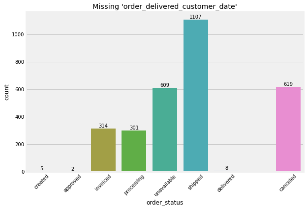

```python
plt.figure(figsize=(9,6))

ax = sns.countplot(data=orders[orders['order_delivered_customer_date'].isna()], x='order_status', order=['created','approved','invoiced','processing','unavailable','shipped','delivered','','canceled'])
rects = ax.patches

for rect in rects:
    height = rect.get_height()
    if pd.isna(height):
        continue
    ax.text(rect.get_x() + rect.get_width() / 2, height, int(height), ha='center', va='bottom')

plt.title("Missing 'order_delivered_customer_date'")
plt.xticks(rotation=45)
plt.show()
```

*- É compreensível que ordens sem o status de "delivered" possuam o campo de data de entrega no cliente em branco, do contrário algum erro deve ter ocorrido.*

### Pedidos sem data de entrega no transportador informadas

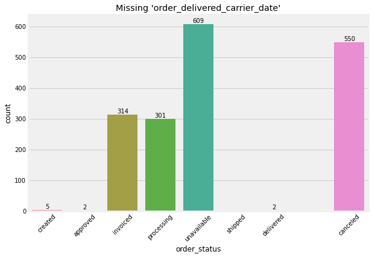

```python
plt.figure(figsize=(9,6))

ax = sns.countplot(data=orders[orders['order_delivered_carrier_date'].isna()], x='order_status', order=['created','approved','invoiced','processing','unavailable','shipped','delivered','','canceled'])
rects = ax.patches

for rect in rects:
    height = rect.get_height()
    if pd.isna(height):
        continue
    ax.text(rect.get_x() + rect.get_width() / 2, height, int(height), ha='center', va='bottom')

plt.title("Missing 'order_delivered_carrier_date'")
plt.xticks(rotation=45)
plt.show()
```

*- É compreensível que ordens que ainda não possuem status de "shipped" ou "delivered" e não foram canceladas possuam o campo de data de entrega no transportador em branco, do contrário algum erro deve ter ocorrido.*

### Decompondo a TimeSeries da entrada de novos pedidos

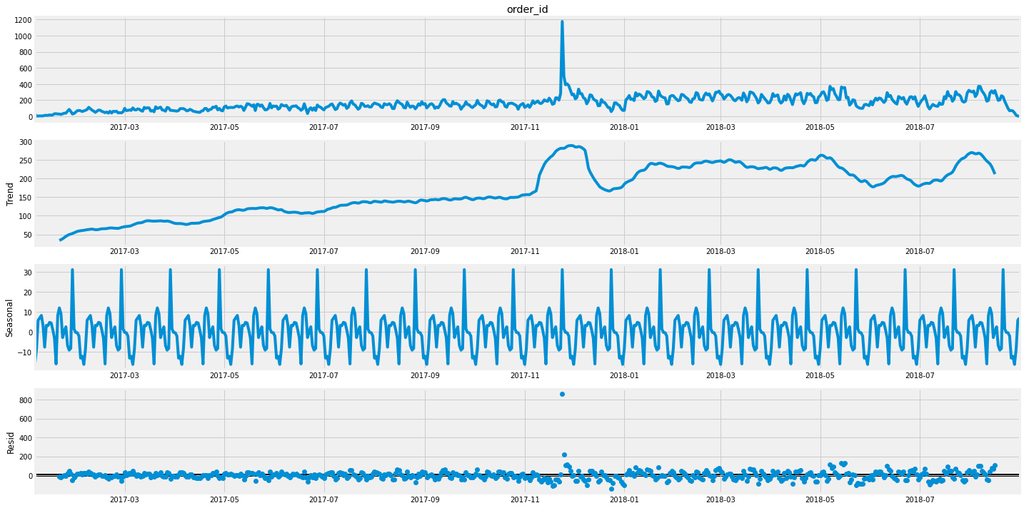

```
Peak sales:
order_purchase_date
2017-11-24    1176
Name: order_id, dtype: int64
```

```python
decomposing = orders.copy()
decomposing['order_purchase_date'] = decomposing.order_purchase_timestamp.dt.date
decomposing = decomposing.groupby(['order_purchase_date'])['order_id'].count()
decomposing = decomposing.sort_index().loc[pd.to_datetime('2017-01-01').date():pd.to_datetime('2018-09-01').date()]

matplotlib.rcParams['figure.figsize'] = [20.0,10.0]

new_orders_dec = seasonal_decompose(decomposing, model='additive', period=30)
new_orders_dec.plot()

plt.show()

print(f"Peak sales: \n{decomposing[decomposing == decomposing.max()]}")
```

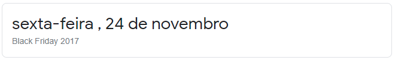

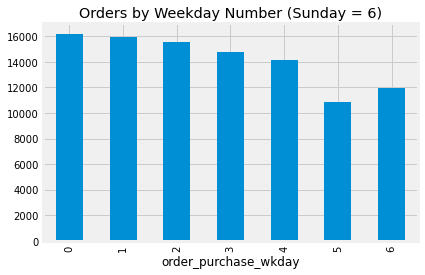

```python
decomposing = orders.copy()
decomposing['order_purchase_wkday'] = decomposing.order_purchase_timestamp.dt.weekday
decomposing = decomposing.groupby(['order_purchase_wkday'])['order_id'].count()
decomposing = decomposing.sort_index()

decomposing.reset_index(drop=False).plot(kind='bar', x='order_purchase_wkday', y='order_id', title='Orders by Weekday Number (Sunday = 6)', legend=None, figsize=(6,4))
plt.show()
```

*- As compras foram mais frequentes de segunda a quinta-feira, sábado sendo o dia em que menos ocorreram, seguido por domingo. Sexta-feira, na prática, também deve ficar parecida com sábado/domingo, pois pode ter sido bem influenciada para cima por conta da Black Friday.*

# Order items DataFrame

```python
print(f"Shape = {order_items.shape}")
order_items.sample(3)
```

```
Shape = (112650, 7)
```

|  | order_id | order_item_id | product_id | seller_id | shipping_limit_date | price | freight_value |
| --- | --- | --- | --- | --- | --- | --- | --- |
| 76949 | af32f548778c455ef24c466f397130b3 | 1 | 5b2bc7f0927cf91077fcb99abcde248a | 7ad32824caee82087b3e2e5f33b1bf32 | 2018-03-28 12:55:47 | 75.00 | 13.89 |
| 41738 | 5f259af82fc248ddda092d4abe371ff1 | 1 | b584de1994f604fa7dfd0b6b9c6c1b99 | a17f621c590ea0fab3d5d883e1630ec6 | 2017-07-05 22:03:29 | 55.13 | 15.14 |
| 1289 | 0300095becf10f9b2993706759522741 | 1 | 59f17be62604541797d4df87ae80cf73 | 4e922959ae960d389249c378d1c939f5 | 2018-07-05 20:35:15 | 89.00 | 9.93 |

```python
order_items.isna().sum()
```

```
order_id               0
order_item_id          0
product_id             0
seller_id              0
shipping_limit_date    0
price                  0
freight_value          0
dtype: int64
```

### Verificando se quando temos mais de um produto na ordem eles sempre são os mesmos ou possuem mesmo "price"/"freight_value"

```python
order_avg_prices = order_items.groupby('order_id')['price'].agg('mean')
order_avg_freights = order_items.groupby('order_id')['freight_value'].agg('mean')
order_items['avg_price'] = order_items['order_id'].apply(lambda x: order_avg_prices[x])
order_items['avg_freight_value'] = order_items['order_id'].apply(lambda x: order_avg_freights[x])
order_items[(order_items['avg_price'] != order_items['price']) | (order_items['avg_freight_value'] != order_items['freight_value'])].head(5)
```

|  | order_id | order_item_id | product_id | seller_id | shipping_limit_date | price | freight_value | avg_price | avg_freight_value |
| --- | --- | --- | --- | --- | --- | --- | --- | --- | --- |
| 80 | 002f98c0f7efd42638ed6100ca699b42 | 1 | d41dc2f2979f52d75d78714b378d4068 | 7299e27ed73d2ad986de7f7c77d919fa | 2017-08-10 09:30:15 | 8.99 | 32.57 | 26.945000 | 19.865000 |
| 81 | 002f98c0f7efd42638ed6100ca699b42 | 2 | 880be32f4db1d9f6e2bec38fb6ac23ab | fa40cc5b934574b62717c68f3d678b6d | 2017-08-10 09:30:15 | 44.90 | 7.16 | 26.945000 | 19.865000 |
| 151 | 005d9a5423d47281ac463a968b3936fb | 1 | fb7a100ec8c7b34f60cec22b1a9a10e0 | d98eec89afa3380e14463da2aabaea72 | 2017-10-24 12:28:16 | 49.99 | 18.12 | 33.323333 | 15.093333 |
| 152 | 005d9a5423d47281ac463a968b3936fb | 2 | 4c3ae5db49258df0784827bdacf3b396 | d98eec89afa3380e14463da2aabaea72 | 2017-10-24 12:28:16 | 24.99 | 13.58 | 33.323333 | 15.093333 |
| 153 | 005d9a5423d47281ac463a968b3936fb | 3 | 4c3ae5db49258df0784827bdacf3b396 | d98eec89afa3380e14463da2aabaea72 | 2017-10-24 12:28:16 | 24.99 | 13.58 | 33.323333 | 15.093333 |

*- Analisando estas duas ordens, podemos perceber que cada produto possui seu próprio valor de frete dentro do pedido, independentemente de ser do mesmo vendedor ou não.*  
*- Também percebemos que quando temos mais de um item por ordem não são necessariamente os mesmos em multiplicidade, porém isto pode ocorrer.*

### Plotando a média móvel do Valor médio vendido por pedido e do Custo do Frete médio por pedido ao decorrer da série temporal com suas respectivas regressões lineares

```python
window_lenght = 10

order_value_and_freight = order_items.groupby('order_id', as_index=False)[['price','freight_value']].agg('sum')
merge = order_value_and_freight.merge(orders[['order_id','order_purchase_timestamp']], on='order_id')
merge['order_purchase_timestamp'] = pd.to_datetime(merge['order_purchase_timestamp']).dt.date
merge.rename(columns={'order_purchase_timestamp':'purchase_date'}, inplace=True)
daily = merge.groupby('purchase_date').agg('mean')
daily[f'{window_lenght}days_ma_price'] = daily['price'].rolling(window_lenght).mean()
daily[f'{window_lenght}days_ma_freight_value'] = daily['freight_value'].rolling(window_lenght).mean()
daily.dropna(inplace=True)

# removing "edge" periods
daily = daily.loc[pd.to_datetime('2017-01-01').date():pd.to_datetime('2018-08-01').date()]
daily.head(3)
```

| purchase_date | price | freight_value | 10days_ma_price | 10days_ma_freight_value |
| --- | --- | --- | --- | --- |
| 2017-01-05 | 12.403125 | 9.699063 | 120.784353 | 20.394874 |
| 2017-01-06 | 229.095000 | 17.975000 | 137.900353 | 20.546624 |
| 2017-01-07 | 337.975000 | 24.022500 | 155.129586 | 20.691340 |

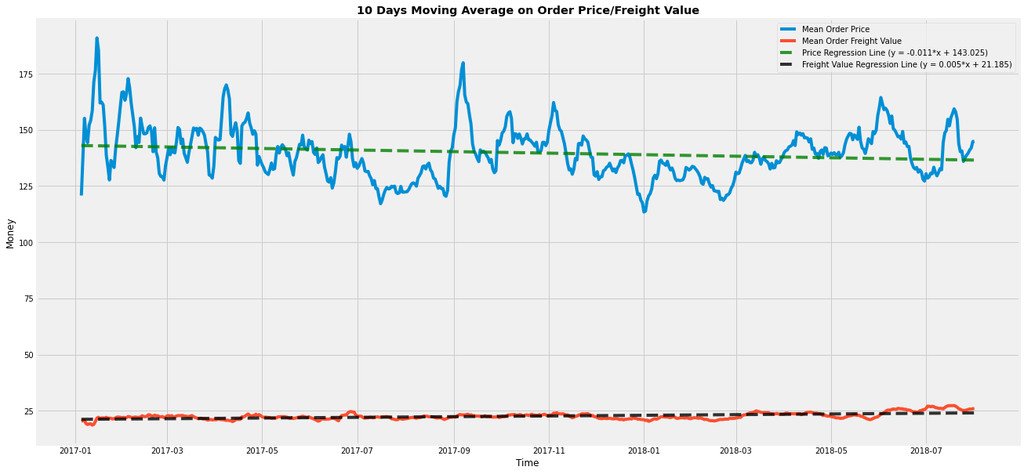

```python
# line 1 points
x1 = daily.index
y1 = daily[f'{window_lenght}days_ma_price']
# plotting the line 1 points
plt.plot(x1, y1, label="Mean Order Price")

# line 2 points
x2 = x1
y2 = daily[f'{window_lenght}days_ma_freight_value']
# plotting the line 2 points
plt.plot(x2, y2, label="Mean Order Freight Value")

# price linear regression line plotting
m1, b1 = np.polyfit(range(len(x1)), y1, 1)
plt.plot(x1, m1*range(len(x1)) + b1, linestyle='--', alpha=0.8, color='green', label=f"Price Regression Line (y = {round(m1,3)}*x + {round(b1,3)})")

# freight value linear regression line plotting
m2, b2 = np.polyfit(range(len(x2)), y2, 1)
plt.plot(x2, m2*range(len(x2)) + b2, linestyle='--', alpha=0.8, color='black', label=f"Freight Value Regression Line (y = {round(m2,3)}*x + {round(b2,3)})")

# Set the x axis label of the current axis.
plt.xlabel('Time')
# Set the y axis label of the current axis.
plt.ylabel('Money')

# Set a title of the current axes.
plt.title(f'{window_lenght} Days Moving Average on Order Price/Freight Value', weight='bold')
# show a legend on the plot
plt.legend()
# Display a figure.
plt.show()
```

*- O valor médio gasto em um pedido vem caindo ao longo do tempo(talvez um pouco influenciado por nao termos a black friday de 2018 nos dados).*  
*- O custo médio de frete por pedido vem crescendo, pode ser que tenha acompanhado o crescimento do valor dos combustíveis.*  
*- Existe um desafio interessante em reduzir este custo médio de frete.*

```python
order_items.describe(percentiles=[.25, .5, .75, .90, .99])
```

|  | order_item_id | price | freight_value | avg_price | avg_freight_value |
| --- | --- | --- | --- | --- | --- |
| count | 112650.000000 | 112650.000000 | 112650.000000 | 112650.000000 | 112650.000000 |
| mean | 1.197834 | 120.653739 | 19.990320 | 120.653739 | 19.990320 |
| std | 0.705124 | 183.633928 | 15.806405 | 183.075301 | 15.614028 |
| min | 1.000000 | 0.850000 | 0.000000 | 0.850000 | 0.000000 |
| 25% | 1.000000 | 39.900000 | 13.080000 | 39.950000 | 13.177500 |
| 50% | 1.000000 | 74.990000 | 16.260000 | 74.990000 | 16.260000 |
| 75% | 1.000000 | 134.900000 | 21.150000 | 134.900000 | 21.100000 |
| 90% | 2.000000 | 229.800000 | 34.041000 | 229.000000 | 33.700000 |
| 99% | 4.000000 | 890.000000 | 84.520000 | 889.000000 | 83.754000 |
| max | 21.000000 | 6735.000000 | 409.680000 | 6735.000000 | 409.680000 |

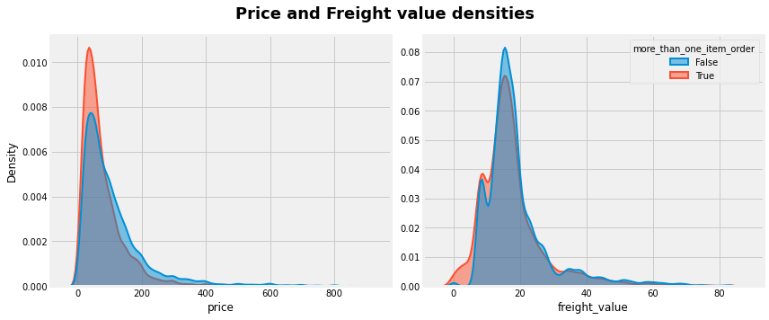

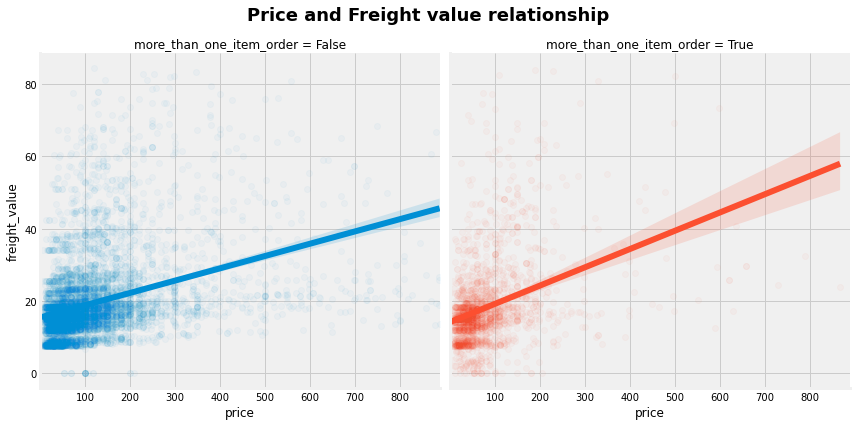

```python
# creating column to identify 'more_than_one_item_order'
order_items['more_than_one_item_order'] = order_items['order_id'].duplicated(keep=False)

# dropping everything above 99th percentile
numerics_to_plot = order_items[['price','freight_value']].copy()
cut = numerics_to_plot.quantile(.99)
numerics_to_plot = numerics_to_plot[numerics_to_plot < cut]
numerics_to_plot['more_than_one_item_order'] = order_items.loc[numerics_to_plot.index, 'more_than_one_item_order']

fig, axs = plt.subplots(1,2, figsize=(12,5))
sns.kdeplot(
   data=numerics_to_plot, x="price", cbar=True, hue='more_than_one_item_order',
   fill=True, common_norm=False,
   alpha=.5, linewidth=2, ax=axs[0], legend=False
)

sns.kdeplot(
   data=numerics_to_plot, x="freight_value", cbar=True, hue='more_than_one_item_order',
   fill=True, common_norm=False, ax=axs[1],
   alpha=.5, linewidth=2,
)
axs[1].set_ylabel("")

fig.suptitle("Price and Freight value densities", fontsize=18, fontweight='bold')
plt.tight_layout()
plt.show()

sns.lmplot(
    data=numerics_to_plot.sample(10000), x="price", y="freight_value",
    hue="more_than_one_item_order", col="more_than_one_item_order", scatter_kws={'alpha':0.03}, height=6, aspect=1,
)
plt.suptitle("Price and Freight value relationship", fontsize=18, fontweight='bold')
plt.tight_layout()
plt.show()
```

*- O preço dos produtos comprados em ordens multi item se concentram um pouco mais, com um desvio padrão menor.*  
*- Na relação linear entre custo de frete e preço do item, quando falamos de ordens multi item o coeficiente angular da reta é ligeiramente maior.*

# Products DataFrame

```python
print(f"Shape = {products.shape}")
products.sample(3)
```

```
Shape = (32951, 9)
```

|  | product_id | product_category_name | product_name_lenght | product_description_lenght | product_photos_qty | product_weight_g | product_length_cm | product_height_cm | product_width_cm |
| --- | --- | --- | --- | --- | --- | --- | --- | --- | --- |
| 10080 | 5f315c482ee138f3766f5a9169f16ba6 | relogios_presentes | 51.0 | 499.0 | 1.0 | 250.0 | 16.0 | 11.0 | 11.0 |
| 21650 | 94976cc078d10e74c19c62f0b3b52432 | cama_mesa_banho | 48.0 | 262.0 | 1.0 | 6150.0 | 52.0 | 16.0 | 44.0 |
| 14343 | 930363fe8355b51e7bb4154214246561 | NaN | NaN | NaN | NaN | 3600.0 | 50.0 | 35.0 | 15.0 |

```python
products.describe(include='all')
```

|  | product_id | product_category_name | product_name_lenght | product_description_lenght | product_photos_qty | product_weight_g | product_length_cm | product_height_cm | product_width_cm |
| --- | --- | --- | --- | --- | --- | --- | --- | --- | --- |
| count | 32951 | 32341 | 32341.000000 | 32341.000000 | 32341.000000 | 32949.000000 | 32949.000000 | 32949.000000 | 32949.000000 |
| unique | 32951 | 73 | NaN | NaN | NaN | NaN | NaN | NaN | NaN |
| top | f175de424f961785861228372285f0be | cama_mesa_banho | NaN | NaN | NaN | NaN | NaN | NaN | NaN |
| freq | 1 | 3029 | NaN | NaN | NaN | NaN | NaN | NaN | NaN |
| mean | NaN | NaN | 48.476949 | 771.495285 | 2.188986 | 2276.472488 | 30.815078 | 16.937661 | 23.196728 |
| std | NaN | NaN | 10.245741 | 635.115225 | 1.736766 | 4282.038731 | 16.914458 | 13.637554 | 12.079047 |
| min | NaN | NaN | 5.000000 | 4.000000 | 1.000000 | 0.000000 | 7.000000 | 2.000000 | 6.000000 |
| 25% | NaN | NaN | 42.000000 | 339.000000 | 1.000000 | 300.000000 | 18.000000 | 8.000000 | 15.000000 |
| 50% | NaN | NaN | 51.000000 | 595.000000 | 1.000000 | 700.000000 | 25.000000 | 13.000000 | 20.000000 |
| 75% | NaN | NaN | 57.000000 | 972.000000 | 3.000000 | 1900.000000 | 38.000000 | 21.000000 | 30.000000 |
| max | NaN | NaN | 76.000000 | 3992.000000 | 20.000000 | 40425.000000 | 105.000000 | 105.000000 | 118.000000 |

*- Existem 73 categorias diferentes de produtos nesta base e cada linha corresponde a um produto diferente.*  
*- Nenhum valor absurdo observado para as colunas numéricas.*

```python
products.isna().sum()
```

```
product_id                      0
product_category_name         610
product_name_lenght           610
product_description_lenght    610
product_photos_qty            610
product_weight_g                2
product_length_cm               2
product_height_cm               2
product_width_cm                2
dtype: int64
```

### Produtos sem informação de peso/tamanho

```python
products[products['product_weight_g'].isna()]
```

|  | product_id | product_category_name | product_name_lenght | product_description_lenght | product_photos_qty | product_weight_g | product_length_cm | product_height_cm | product_width_cm |
| --- | --- | --- | --- | --- | --- | --- | --- | --- | --- |
| 8578 | 09ff539a621711667c43eba6a3bd8466 | bebes | 60.0 | 865.0 | 3.0 | NaN | NaN | NaN | NaN |
| 18851 | 5eb564652db742ff8f28759cd8d2652a | NaN | NaN | NaN | NaN | NaN | NaN | NaN | NaN |

*- Seria possível de preencher estes campos vazios utilizando a média ou mediana da categoria (no último caso primeiro seria necessário classificar sua categoria).*

### Produtos sem informação de categoria/descrição

```python
products[products['product_category_name'].isna()].sample(3)
```

|  | product_id | product_category_name | product_name_lenght | product_description_lenght | product_photos_qty | product_weight_g | product_length_cm | product_height_cm | product_width_cm |
| --- | --- | --- | --- | --- | --- | --- | --- | --- | --- |
| 27504 | cef16b173166d8d44b4fbf05b4b43bec | NaN | NaN | NaN | NaN | 1600.0 | 45.0 | 12.0 | 30.0 |
| 30337 | 2d188e4d3435b1bf29dfd385b324de2c | NaN | NaN | NaN | NaN | 800.0 | 39.0 | 12.0 | 17.0 |
| 27554 | 80872f7f128200f12c5af9494b1d37a0 | NaN | NaN | NaN | NaN | 1100.0 | 23.0 | 16.0 | 13.0 |

*- Podemos utilizar o comportamento de vendas destes produtos ao longo da timeseries, junto com suas informações de peso/medida/vendedor e custo de frete, para encaixa-los na categoria que possui comportamento mais semelhante. Com isto, é possível também trazer a média ou mediana da categoria para cada campo vazio(ou criar modelos para atribuir estes valores faltantes).*

## Order Reviews DataFrame

```python
print("Shape =", order_reviews.shape)
display(order_reviews.sample(3))
```

```
Shape = (100000, 7)
```

|  | review_id | order_id | review_score | review_comment_title | review_comment_message | review_creation_date | review_answer_timestamp |
| --- | --- | --- | --- | --- | --- | --- | --- |
| 77652 | 345814b995aff9c54fdc2da7164ac6e2 | 9703eb84b4433601ca6171b79e26ce1c | 5 | NaN | atendeu as minhas expectativas | 2017-09-12 00:00:00 | 2017-09-14 02:08:51 |
| 48453 | 0726eb28a3d928fe74e24b07c6c47621 | 10010d54b0ddcd2c4ef9076ac5b16e2c | 5 | NaN | NaN | 2017-12-17 00:00:00 | 2017-12-20 01:13:07 |
| 93700 | 656585c1dde315ff1cf925b44e2e8c2f | 6f64e74ecd4ed3196bd31cf14d1967bd | 5 | NaN | Produto de exelente qualidade, recomendo pois ... | 2017-04-15 00:00:00 | 2017-04-17 01:52:22 |

```python
order_reviews.isna().sum()
```

```
review_id                      0
order_id                       0
review_score                   0
review_comment_title       88285
review_comment_message     58247
review_creation_date           0
review_answer_timestamp        0
dtype: int64
```

*- Nem todos os reviews tiverem titulo ou mensagem, são campos opicionais.*

```python
order_reviews.describe(include='all')
```

|  | review_id | order_id | review_score | review_comment_title | review_comment_message | review_creation_date | review_answer_timestamp |
| --- | --- | --- | --- | --- | --- | --- | --- |
| count | 100000 | 100000 | 100000.000000 | 11715 | 41753 | 100000 | 100000 |
| unique | 99173 | 99441 | NaN | 4600 | 36921 | 637 | 99010 |
| top | e44840754f12fad2b8646712121b349a | 03c939fd7fd3b38f8485a0f95798f1f6 | NaN | Recomendo | Muito bom | 2017-12-19 00:00:00 | 2017-06-15 23:21:05 |
| freq | 3 | 3 | NaN | 426 | 230 | 466 | 4 |
| mean | NaN | NaN | 4.070890 | NaN | NaN | NaN | NaN |
| std | NaN | NaN | 1.359663 | NaN | NaN | NaN | NaN |
| min | NaN | NaN | 1.000000 | NaN | NaN | NaN | NaN |
| 25% | NaN | NaN | 4.000000 | NaN | NaN | NaN | NaN |
| 50% | NaN | NaN | 5.000000 | NaN | NaN | NaN | NaN |
| 75% | NaN | NaN | 5.000000 | NaN | NaN | NaN | NaN |
| max | NaN | NaN | 5.000000 | NaN | NaN | NaN | NaN |

Visualizando casos onde o "review_id" se repete em mais de uma ordem:

```python
order_reviews[order_reviews['review_id'].duplicated(keep=False)].sort_values(by='review_id').head(6)
```

|  | review_id | order_id | review_score | review_comment_title | review_comment_message | review_creation_date | review_answer_timestamp |
| --- | --- | --- | --- | --- | --- | --- | --- |
| 47045 | 00130cbe1f9d422698c812ed8ded1919 | dfcdfc43867d1c1381bfaf62d6b9c195 | 1 | NaN | O cartucho "original HP" 60XL não é reconhecid... | 2018-03-07 00:00:00 | 2018-03-20 18:08:23 |
| 30062 | 00130cbe1f9d422698c812ed8ded1919 | 04a28263e085d399c97ae49e0b477efa | 1 | NaN | O cartucho "original HP" 60XL não é reconhecid... | 2018-03-07 00:00:00 | 2018-03-20 18:08:23 |
| 63695 | 0115633a9c298b6a98bcbe4eee75345f | 0c9850b2c179c1ef60d2855e2751d1fa | 5 | NaN | NaN | 2017-09-21 00:00:00 | 2017-09-26 03:27:47 |
| 91399 | 0115633a9c298b6a98bcbe4eee75345f | 78a4201f58af3463bdab842eea4bc801 | 5 | NaN | NaN | 2017-09-21 00:00:00 | 2017-09-26 03:27:47 |
| 57727 | 0174caf0ee5964646040cd94e15ac95e | 74db91e33b4e1fd865356c89a61abf1f | 1 | NaN | Produto entregue dentro de embalagem do fornec... | 2018-03-07 00:00:00 | 2018-03-08 03:00:53 |
| 93607 | 0174caf0ee5964646040cd94e15ac95e | f93a732712407c02dce5dd5088d0f47b | 1 | NaN | Produto entregue dentro de embalagem do fornec... | 2018-03-07 00:00:00 | 2018-03-08 03:00:53 |

*- Existem casos ondem um mesmo review se aplicou para mais de uma ordem, pode significar que o review é feito no nível de frete, se mais de uma ordem chega ao cliente no mesmo frete então todas terão o mesmo review. Também pode ter alguma relação com trocas(talvez um novo pedido com o item idêntico seja criado e os atributos do pedido original copiados para ele).*

Visualizando casos onde a "order_id" se repete em mais de um review:

```python
order_reviews[order_reviews['order_id'].duplicated(keep=False)].sort_values(by='order_id').tail(6)
```

|  | review_id | order_id | review_score | review_comment_title | review_comment_message | review_creation_date | review_answer_timestamp |
| --- | --- | --- | --- | --- | --- | --- | --- |
| 95246 | c56a88a404315a0d9e412c1472dda2c4 | ff763b73e473d03c321bcd5a053316e8 | 5 | NaN | NaN | 2017-11-01 00:00:00 | 2017-11-01 19:55:52 |
| 27663 | 5e78482ee783451be6026e5cf0c72de1 | ff763b73e473d03c321bcd5a053316e8 | 3 | NaN | Não sei que haverá acontecido os demais chegaram | 2017-11-18 00:00:00 | 2017-11-18 09:02:48 |
| 41665 | 39de8ad3a1a494fc68cc2d5382f052f4 | ff850ba359507b996e8b2fbb26df8d03 | 5 | NaN | Envio rapido... Produto 100% | 2017-08-16 00:00:00 | 2017-08-17 11:56:55 |
| 18916 | 80f25f32c00540d49d57796fb6658535 | ff850ba359507b996e8b2fbb26df8d03 | 5 | NaN | Envio rapido, produto conforme descrito no anu... | 2017-08-22 00:00:00 | 2017-08-25 11:40:22 |
| 54388 | 5476dd0eaee7c4e2725cafb011aa758c | ffaabba06c9d293a3c614e0515ddbabc | 3 | NaN | NaN | 2017-12-20 00:00:00 | 2017-12-21 13:24:55 |
| 92957 | 870d856a4873d3a67252b0c51d79b950 | ffaabba06c9d293a3c614e0515ddbabc | 3 | NaN | NaN | 2017-12-20 00:00:00 | 2017-12-20 18:50:16 |

*- Talvez o review ocorra junto a confirmação da entrega e caso seja alterado/respondido mais de uma vez é criado um novo review na base de dados*

### Plotando engajamento em comentários e score médio ao longo do período observado

```python
window_lenght = 30
score_per_day = order_reviews[order_reviews['review_comment_message'].notna()].groupby('review_creation_date', as_index=False)[['review_score','review_comment_message']].agg({'review_comment_message':'count', 'review_score':'mean'})
score_per_day['review_creation_date'] = pd.to_datetime(score_per_day['review_creation_date']).dt.date
score_per_day.set_index('review_creation_date', inplace=True)
score_per_day[f'{window_lenght}days_ma_review_score'] = score_per_day['review_score'].rolling(window_lenght).mean()
score_per_day[f'{window_lenght}days_ma_review_comment_message'] = score_per_day['review_comment_message'].rolling(window_lenght).mean()

score_per_day.dropna(inplace=True)

# removing "edge" periods
score_per_day = score_per_day.loc[pd.to_datetime('2017-03-01').date():pd.to_datetime('2018-08-01').date()]
score_per_day.head()
```

| review_creation_date | review_comment_message | review_score | 30days_ma_review_score | 30days_ma_review_comment_message |
| --- | --- | --- | --- | --- |
| 2017-03-01 | 1 | 5.000000 | 3.926595 | 22.000000 |
| 2017-03-02 | 31 | 3.935484 | 3.907778 | 22.500000 |
| 2017-03-03 | 45 | 3.911111 | 3.883602 | 23.633333 |
| 2017-03-04 | 46 | 3.847826 | 3.872974 | 24.966667 |
| 2017-03-05 | 14 | 3.214286 | 3.868523 | 24.666667 |

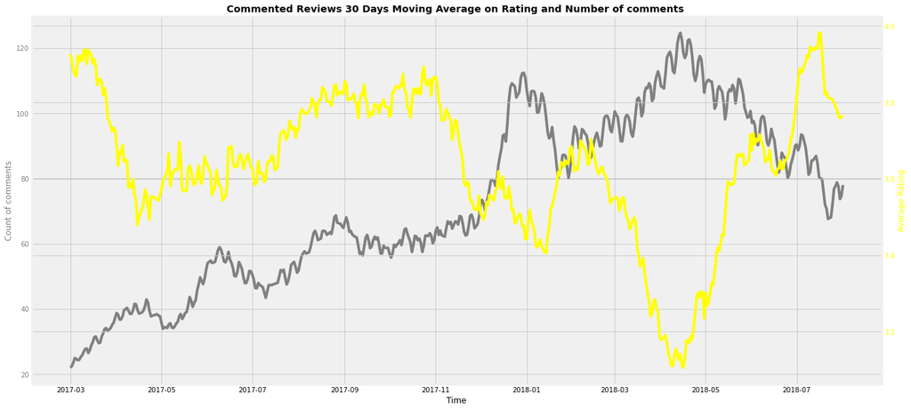

```python
t = score_per_day.index
data1 = score_per_day[f'{window_lenght}days_ma_review_comment_message']
data2 = score_per_day[f'{window_lenght}days_ma_review_score']

fig, ax1 = plt.subplots()

color = 'gray'
ax1.set_xlabel('Time')
ax1.set_ylabel('Count of comments', color=color)
ax1.plot(t, data1, color=color)
ax1.tick_params(axis='y', labelcolor=color)

ax2 = ax1.twinx()

color = 'yellow'
ax2.set_ylabel('Average Rating', color=color)
ax2.plot(t, data2, color=color)
ax2.tick_params(axis='y', labelcolor=color)

plt.title(f'Commented Reviews {window_lenght} Days Moving Average on Rating and Number of comments ', weight='bold')
plt.show()
```

*- Percebemos que quando o número de comentários sobe geralmente o rating desce, sendo praticamente inversamente proporcionais.*  
*- Isto nos faz perceber que o consumidor se dará ao trabalho comentar muito mais em momentos de insatisfação do que em momentos de satisfação com o produto/entrega.*

#### Com isto finalizo esta primeira investigação nos datasets, diversas questões ainda estão pendentes de serem respondidas, porém aqui tentei me limitar a investigar um por um da maneira mais individual possível, entendendo o processo de coleta dos dados, alguns comportamentos do negócio e adquirindo um bom direcionamento para que possa fazer as perguntas corretas para os dados(e se possível para quem forneceu eles também) nos próximos passos.

# Author: Gabriel Tardochi Salles

### LinkedIn: https://www.linkedin.com/in/gabriel-tardochi-salles-a1653a193/

### GitHub Portfolio: https://github.com/ga-tardochisalles

### Medium: https://ga-tardochisalles.medium.com/